# Wine-Clustering-Minh

Minh

1/4/2022

#### Housekeeping

```r
rm(list=ls()) # clear workspace
cat("\014")  # clear console
```

```r
graphics.off() # shuts down all open graphics devices
```

#### Load Data

```r
X <- read.csv("/Users/ptm01/Desktop/Analytics Portfolio/Wine - Winter Data Comp/winequality-red.csv")
head(X)
```

```
##   fixed.acidity volatile.acidity citric.acid residual.sugar chlorides
## 1           7.4             0.70        0.00            1.9     0.076
## 2           7.8             0.88        0.00            2.6     0.098
## 3           7.8             0.76        0.04            2.3     0.092
## 4          11.2             0.28        0.56            1.9     0.075
## 5           7.4             0.70        0.00            1.9     0.076
## 6           7.4             0.66        0.00            1.8     0.075
##   free.sulfur.dioxide total.sulfur.dioxide density   pH sulphates alcohol
## 1                  11                   34  0.9978 3.51      0.56     9.4
## 2                  25                   67  0.9968 3.20      0.68     9.8
## 3                  15                   54  0.9970 3.26      0.65     9.8
## 4                  17                   60  0.9980 3.16      0.58     9.8
## 5                  11                   34  0.9978 3.51      0.56     9.4
## 6                  13                   40  0.9978 3.51      0.56     9.4
##   quality
## 1       5
## 2       5
## 3       5
## 4       6
## 5       5
## 6       5
```

## K-Means Clustering

Source for guidance: https://uc-r.github.io/kmeans_clustering

Libraries

```r
library(tidyverse)
library(cluster)
library(factoextra)
```

Set-up dataset: scaling/standardizing the data

```r
X <- scale(X)
head(X)
```

```
##      fixed.acidity volatile.acidity citric.acid residual.sugar   chlorides
## [1,]    -0.5281944        0.9615758   -1.391037    -0.45307667 -0.24363047
## [2,]    -0.2984541        1.9668271   -1.391037     0.04340257  0.22380518
## [3,]    -0.2984541        1.2966596   -1.185699    -0.16937425  0.09632273
## [4,]     1.6543385       -1.3840105    1.483689    -0.45307667 -0.26487754
## [5,]    -0.5281944        0.9615758   -1.391037    -0.45307667 -0.24363047
## [6,]    -0.5281944        0.7381867   -1.391037    -0.52400227 -0.26487754
##      free.sulfur.dioxide total.sulfur.dioxide    density         pH   sulphates
## [1,]         -0.46604672           -0.3790141 0.55809987  1.2882399 -0.57902538
## [2,]          0.87236532            0.6241680 0.02825193 -0.7197081  0.12891007
## [3,]         -0.08364328            0.2289750 0.13422152 -0.3310730 -0.04807379
## [4,]          0.10755844            0.4113718 0.66406945 -0.9787982 -0.46103614
## [5,]         -0.46604672           -0.3790141 0.55809987  1.2882399 -0.57902538
## [6,]         -0.27484500           -0.1966174 0.55809987  1.2882399 -0.57902538
##         alcohol    quality
## [1,] -0.9599458 -0.7875763
## [2,] -0.5845942 -0.7875763
## [3,] -0.5845942 -0.7875763
## [4,] -0.5845942  0.4507074
## [5,] -0.9599458 -0.7875763
## [6,] -0.9599458 -0.7875763
```

Measuring CLustering Distance

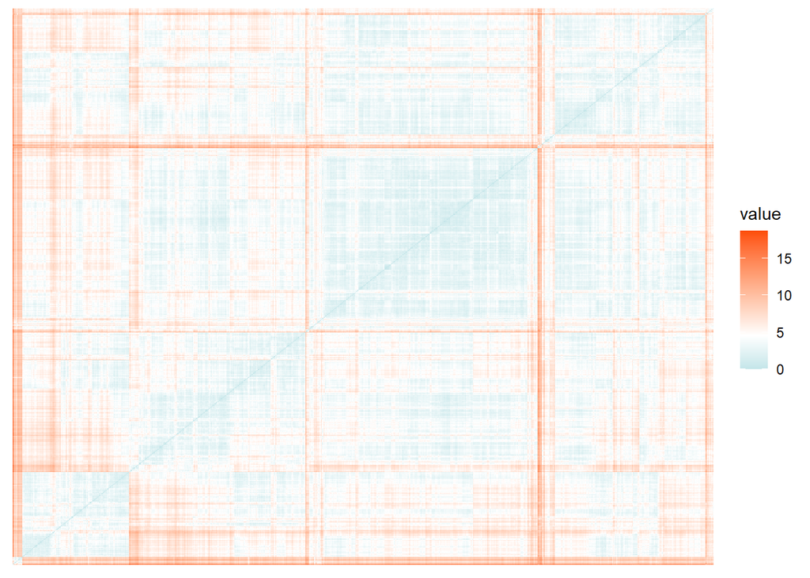

```r
distance <- get_dist(X)
fviz_dist(distance, show_labels = FALSE, gradient = list(low = "#00AFBB", mid = "white", high = "#FC4E07"))
```

Set center to 3, based on EDA.

```r
kmc3 <- kmeans(X, centers = 3, nstart = 25)
str(kmc3)
```

```
## List of 9
##  $ cluster     : int [1:1599] 3 2 3 1 3 3 3 3 3 2 ...
##  $ centers     : num [1:3, 1:12] 0.9478 -0.0659 -0.6464 -0.7293 0.0497 ...
##   ..- attr(*, "dimnames")=List of 2
##   .. ..$ : chr [1:3] "1" "2" "3"
##   .. ..$ : chr [1:12] "fixed.acidity" "volatile.acidity" "citric.acid" "residual.sugar" ...
##  $ totss       : num 19176
##  $ withinss    : num [1:3] 5609 3751 4666
##  $ tot.withinss: num 14027
##  $ betweenss   : num 5149
##  $ size        : int [1:3] 506 391 702
##  $ iter        : int 4
##  $ ifault      : int 0
##  - attr(*, "class")= chr "kmeans"
```

Result

```r
kmc3
```

```
## K-means clustering with 3 clusters of sizes 506, 391, 702
##
## Cluster means:
##   fixed.acidity volatile.acidity citric.acid residual.sugar   chlorides
## 1     0.9477509      -0.72929480  1.00646211     0.03702487  0.24118915
## 2    -0.0659228       0.04973665  0.09936734     0.36293058 -0.00295708
## 3    -0.6464190       0.49797171 -0.78080122    -0.22883254 -0.17220156
##   free.sulfur.dioxide total.sulfur.dioxide    density         pH  sulphates
## 1          -0.4276930           -0.4643849  0.3636687 -0.7275167  0.5872260
## 2           1.0223682            1.2690096  0.2964553 -0.1717095 -0.1832635
## 3          -0.2611586           -0.3720855 -0.4272512  0.6200311 -0.3211970
##       alcohol    quality
## 1  0.38154044  0.5632786
## 2 -0.55127497 -0.4423770
## 3  0.03203569 -0.1596148
```

[output cut: 55 more lines]

#### Let’s Visualize the result

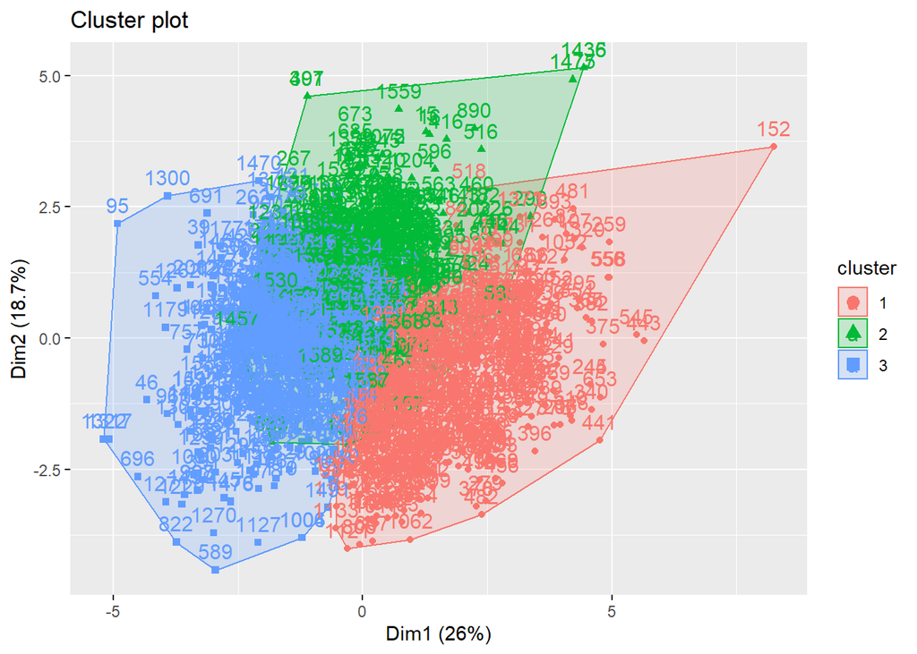

```r
fviz_cluster(kmc3, data = X)
```

3 clusters seems to make the most sense. However, let’s try different cluster settings to make sure! The wine score goes from 1-9, so we’ll try to do up to 9 clusters.

```r
kmc2 <- kmeans(X, centers = 2, nstart = 25)
kmc4 <- kmeans(X, centers = 4, nstart = 25)
kmc5 <- kmeans(X, centers = 5, nstart = 25)
kmc6 <- kmeans(X, centers = 6, nstart = 25)
kmc7 <- kmeans(X, centers = 7, nstart = 25)
kmc8 <- kmeans(X, centers = 8, nstart = 25)
kmc9 <- kmeans(X, centers = 9, nstart = 25)

# plots to compare
p1 <- fviz_cluster(kmc2, geom = "point", data = X) + ggtitle("k = 2")
p2 <- fviz_cluster(kmc3, geom = "point", data = X) + ggtitle("k = 3")
p3 <- fviz_cluster(kmc4, geom = "point", data = X) + ggtitle("k = 4")
p4 <- fviz_cluster(kmc5, geom = "point", data = X) + ggtitle("k = 5")
p5 <- fviz_cluster(kmc6, geom = "point", data = X) + ggtitle("k = 6")
p6 <- fviz_cluster(kmc7, geom = "point", data = X) + ggtitle("k = 7")
p7 <- fviz_cluster(kmc8, geom = "point", data = X) + ggtitle("k = 8")
p8 <- fviz_cluster(kmc9, geom = "point", data = X) + ggtitle("k = 9")
```

```r
library(gridExtra)
```

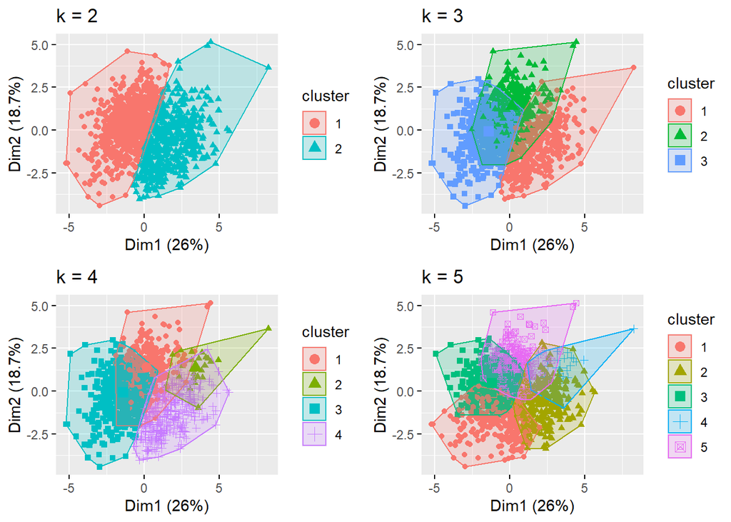

```r
grid.arrange(p1, p2, p3, p4, nrow = 2)
```

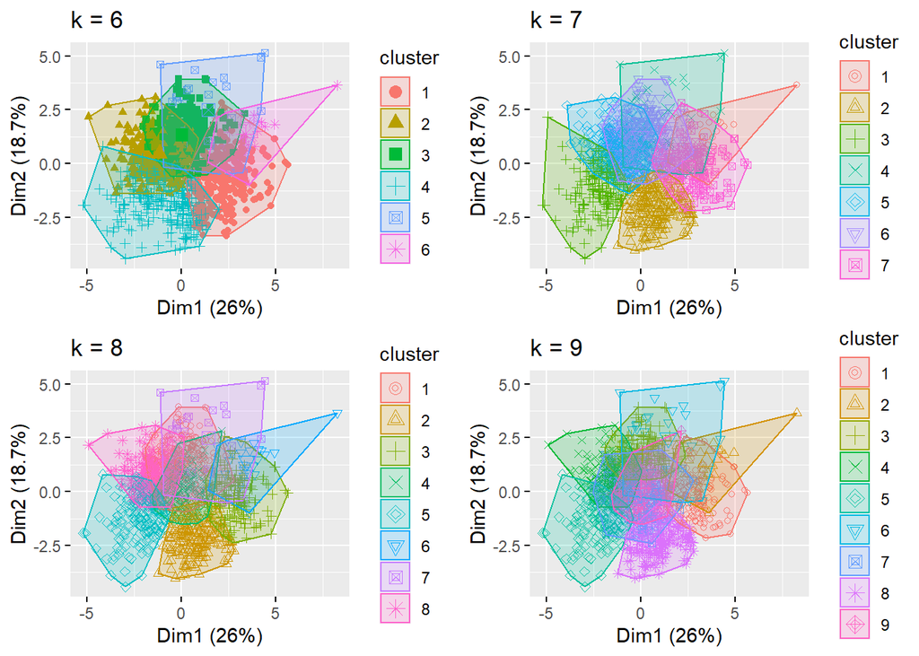

```r
grid.arrange(p5, p6, p7, p8, nrow = 2)
```

More than 5 doesn’t make any sense. 4 clusters look too much. Looks like it could be between 2 or 3 clusters.

#### Determine Optimal Number of Clusters

3 different methods: Elbow, Silhouette, Gap Statistics

#### 1. Elbow Method

1. Compute clustering algorithm (e.g., k-means clustering) for different values of k
2. For each k, calculate the total within-cluster sum of square (wss)
3. Plot the curve of wss according to the number of clusters k.
4. The location of a bend (knee) in the plot is generally considered as an indicator of the appropriate number of clusters.

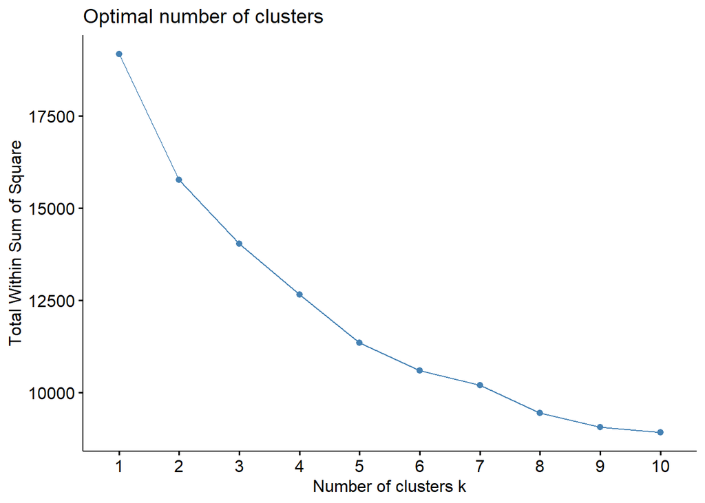

```r
set.seed(123)
fviz_nbclust(X, kmeans, method = "wss")
```

Looks like the elbow is not clear. Let’s try other methods.

#### 2. Silhouette Method

Silhouette Method measures the quality of a clustering. 1. Compute the average silhouette of observations for different values of k. 2. The optimal number of clusters k is the one that maximizes the average silhouette over a range of possible values for k.

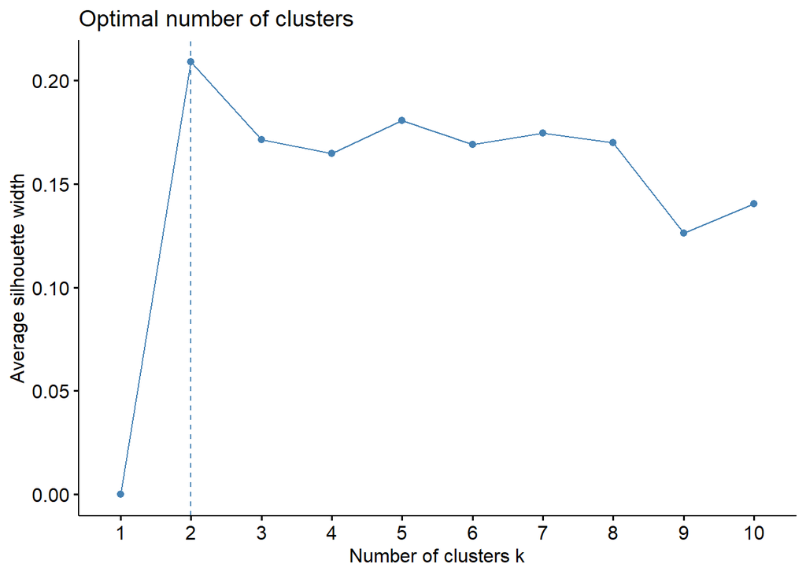

```r
fviz_nbclust(X, kmeans, method = "silhouette")
```

Very interesting, it looks like the optimal number of clusters is 2, not 3 like our original hypothesis.

#### 3. Gap Statistic

Pubished by 3 professors from Standford. http://web.stanford.edu/~hastie/Papers/gap.pdf

Compute the gap statistic

```r
set.seed(123)
gap_stat <- clusGap(X, FUN = kmeans, nstart = 25, K.max = 9, B = 50)
```

[output not shown]

Visualize the Gap Statistic

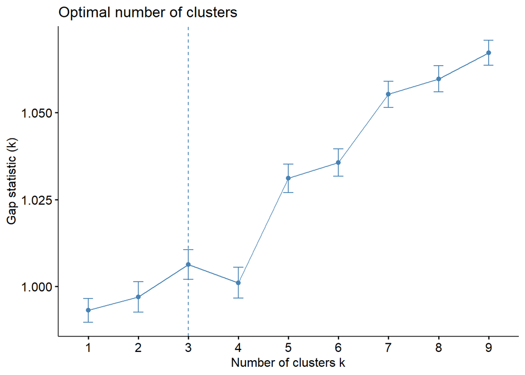

```r
fviz_gap_stat(gap_stat)
```

Looks like 3 is the answer here using this method.

Let’s proceed with 3 clusters.

```r
set.seed(123)
finalclusters <- kmeans(X, 3, nstart = 25)
print(finalclusters)
```

```
## K-means clustering with 3 clusters of sizes 389, 704, 506
##
## Cluster means:
##   fixed.acidity volatile.acidity citric.acid residual.sugar    chlorides
## 1   -0.05970723       0.05595957   0.1004318     0.36566736 -0.001173487
## 2   -0.64820431       0.49325980  -0.7788889    -0.22866362 -0.172706284
## 3    0.94775088      -0.72929480   1.0064621     0.03702487  0.241189151
##   free.sulfur.dioxide total.sulfur.dioxide    density         pH  sulphates
## 1           1.0241225            1.2737317  0.2991146 -0.1762184 -0.1936646
## 2          -0.2584815           -0.3700325 -0.4266647  0.6202733 -0.3150580
## 3          -0.4276930           -0.4643849  0.3636687 -0.7275167  0.5872260
##       alcohol    quality
## 1 -0.55496332 -0.4406022
## 2  0.03241658 -0.1613987
## 3  0.38154044  0.5632786
```

[output cut: 55 more lines]

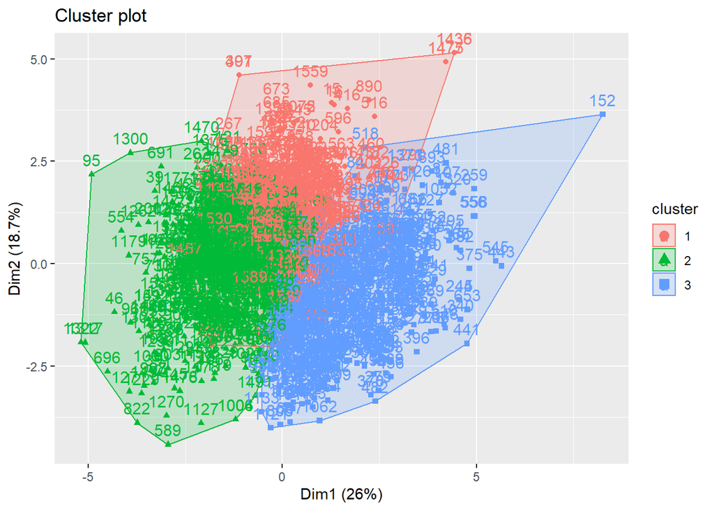

```r
fviz_cluster(finalclusters, data = X)
```

```r
datared <- read.csv("/Users/ptm01/Desktop/Analytics Portfolio/Wine - Winter Data Comp/winequality-red.csv")
datared <- datared %>%
  mutate(Cluster = finalclusters$cluster) %>%
  group_by(Cluster)
```

```r
head(datared, n = 50)
```

```
## # A tibble: 50 x 13
## # Groups:   Cluster [3]
##    fixed.acidity volatile.acidity citric.acid residual.sugar chlorides
##            <dbl>            <dbl>       <dbl>          <dbl>     <dbl>
##  1           7.4             0.7         0               1.9     0.076
##  2           7.8             0.88        0               2.6     0.098
##  3           7.8             0.76        0.04            2.3     0.092
##  4          11.2             0.28        0.56            1.9     0.075
##  5           7.4             0.7         0               1.9     0.076
##  6           7.4             0.66        0               1.8     0.075
##  7           7.9             0.6         0.06            1.6     0.069
##  8           7.3             0.65        0               1.2     0.065
##  9           7.8             0.58        0.02            2       0.073
## 10           7.5             0.5         0.36            6.1     0.071
## # ... with 40 more rows, and 8 more variables: free.sulfur.dioxide <dbl>,
## #   total.sulfur.dioxide <dbl>, density <dbl>, pH <dbl>, sulphates <dbl>,
## #   alcohol <dbl>, quality <int>, Cluster <int>
```